# TMDB Movie Analysis

## Introduction

This document explores a TMDB 5000 Movie Dataset.

The main purpose of this investigation is to find what makes the movie success, in other words, what can effect on the Revenue and the Rating of the movie, are the most popular movies make more money than others? does the actor effects on the movie popularity, and so on.

## Exploratory Data Analysis

### Univariate Analysis:

### Q1: who is the actor with the largest number of movies

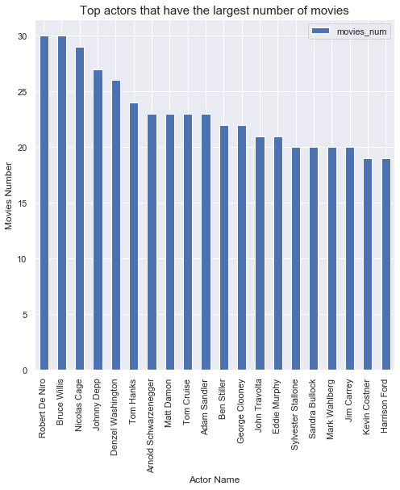

It seems that Robert De Niro has the largest number of movies, Followed by Bruce Willis and both have 30 movies,  
Let's see how this look like in graph.

### Q2: What are the Top production Companies with higher number of Release?

[figure not shown]

Paramount Pictures Company is the top company that makes movies with 281 movie, magnificen!!!

### Q3: What are the TopCountries with higher number of Release?

[figure not shown]

United States of America is the top country which made 3102

### Bivariate Analysis:

### Q1: Which year has the highest release of movies?

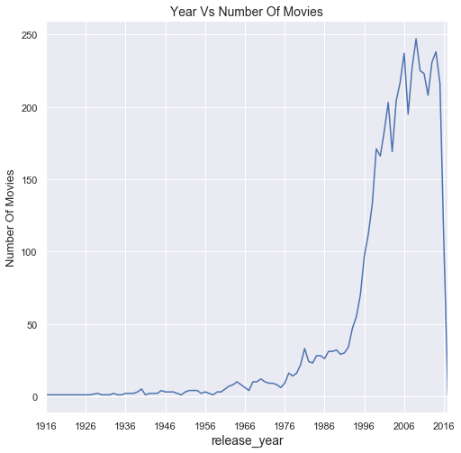

It seems that release of movies increases by year, The year with the highest released movies is 2009

### Q2: What is the highest budget movies

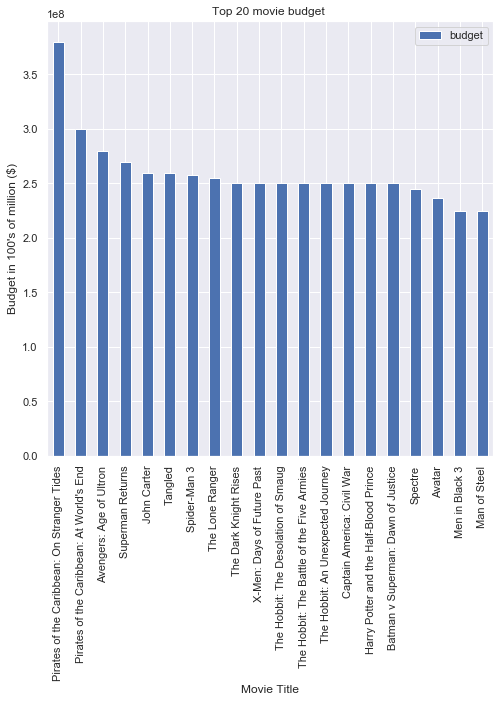

The movie with the Largest budget is 'Pirates of the Caribbean: On Stranger Tides', let's graph the result.

### Q3: Which movie has the maximum popularity?

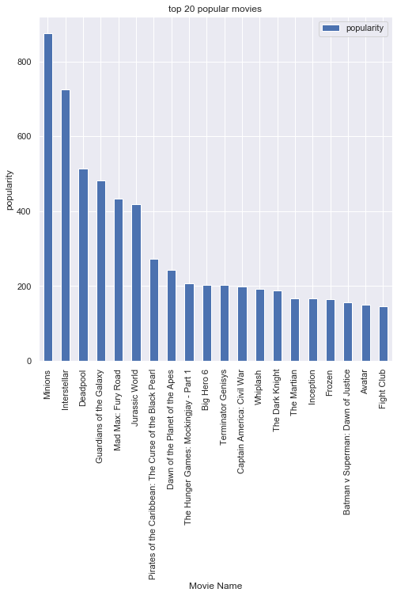

It seems that 'Minions' is most popular movie.

### Q4: Which Directors are most successful (Revenue\ Rating)?

The directors are a strong factor in movies success, we will see who the top directors are.

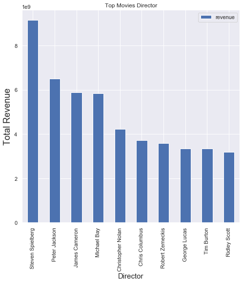

Looks like Steven Spielberg is the most succesful director acording to the movies revenue,  
We are going to plot it and see how it looks.

### Q5: Which movies have the highest vote_average? doese vote_average associated with any other movie properties?

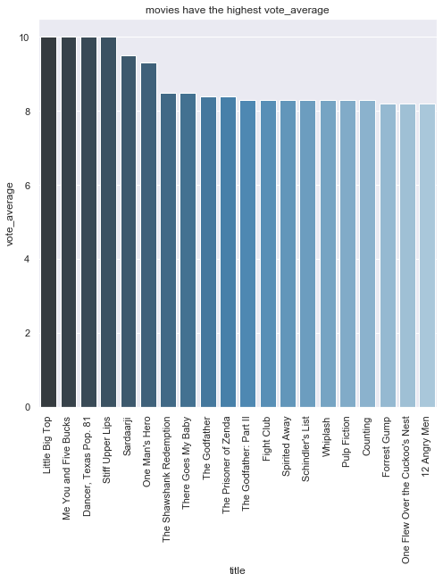

The top three movies according to voting are: Little Big Top, Me You and Five Bucks, Dancer, Texas Pop. 81

### Multivariate Analysis:

### Q1: What is the relation between the actor appearence and the movie and it's popularity?

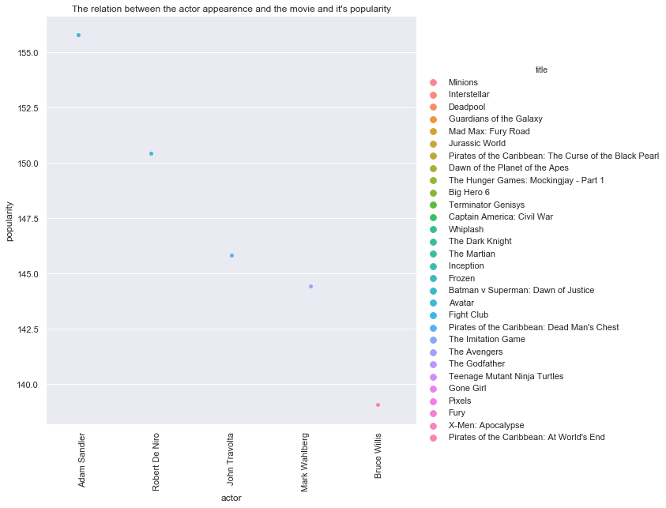

From this results, It seems that the actor name doesnot affect on movies popularity, but let's see how it looks on Graphs

### Q2: Movies with Longest and Shortest Runtime? Is there a Relation between Runtime and Rating?

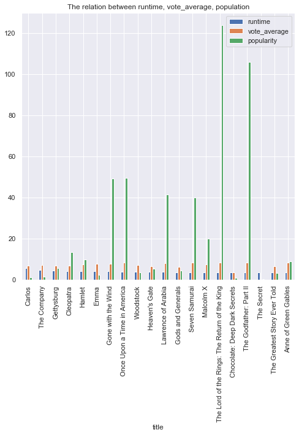

From the information above, it doesnot seem that Poplution, Rate_average and Runtime strongly depends on each other.

### Q3: Which countries that make most Popular Movies?

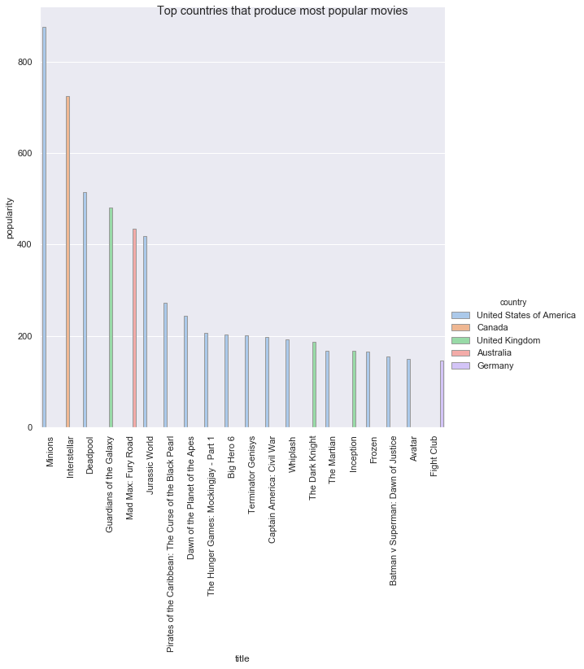

United States of America is the country made 'Minions', which is most popular.

## Q4: The correlation between Movie properties

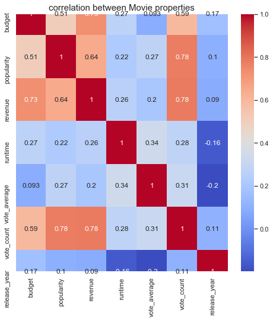

A brief description of the above plot: We are interested in revenue:

seems to be increasing with popularity, with Correlation near to 0.64

also there is a quiet strong relation between it and budget, with Correlation = 0.73

The correlation between revenue and vote average is 0.2. So vote average is not highly related to the revenue.

The correlation between revenue and runtime is 0.26. So runtime is not highly related to the revenue.